# **Analysis Of Movies In R From Year 1960-2020**

## Using t.test for checking if mean can be 7

```r
t.test(mov$IMDb, mu=7.0)
```

```
##
##  One Sample t-test
##
## data:  mov$IMDb
## t = -5.1864, df = 937, p-value = 2.628e-07
## alternative hypothesis: true mean is not equal to 7
## 95 percent confidence interval:
##  6.829538 6.923128
## sample estimates:
## mean of x
##  6.876333
```

**As p-value<0.05, it’s unlikely that true mean is 7**

**Null hypothesis is rejected**

## Using t.test checking if mean is 7 with a confidence level of 99%

```r
t.test(mov$IMDb,conf.level = 0.99, mu=7.0)
```

```
##
##  One Sample t-test
##
## data:  mov$IMDb
## t = -5.1864, df = 937, p-value = 2.628e-07
## alternative hypothesis: true mean is not equal to 7
## 99 percent confidence interval:
##  6.814788 6.937878
## sample estimates:
## mean of x
##  6.876333
```

**p-value is very small so it is very unlikely that mean is 7**

**Null hypothesis is rejected**

## Calculating confidence interval for median of IMDb using Wilcox test

```r
wilcox.test(mov$IMDb,conf.int = TRUE)
```

```
##
##  Wilcoxon signed rank test with continuity correction
##
## data:  mov$IMDb
## V = 440391, p-value < 2.2e-16
## alternative hypothesis: true location is not equal to 0
## 95 percent confidence interval:
##  6.849951 6.900019
## sample estimates:
## (pseudo)median
##       6.850063
```

## Checking if correlation between IMDb and Runtime is significant.

```r
cor.test(mov$IMDb,mov$Runtime)
```

```
##
##  Pearson's product-moment correlation
##
## data:  mov$IMDb and mov$Runtime
## t = 7.3629, df = 936, p-value = 3.941e-13
## alternative hypothesis: true correlation is not equal to 0
## 95 percent confidence interval:
##  0.1725578 0.2935962
## sample estimates:
##       cor
## 0.2339834
```

**p-value<0.05 so a significant correlation exist**

# **Visualizing the Data**

## Univariate analysis

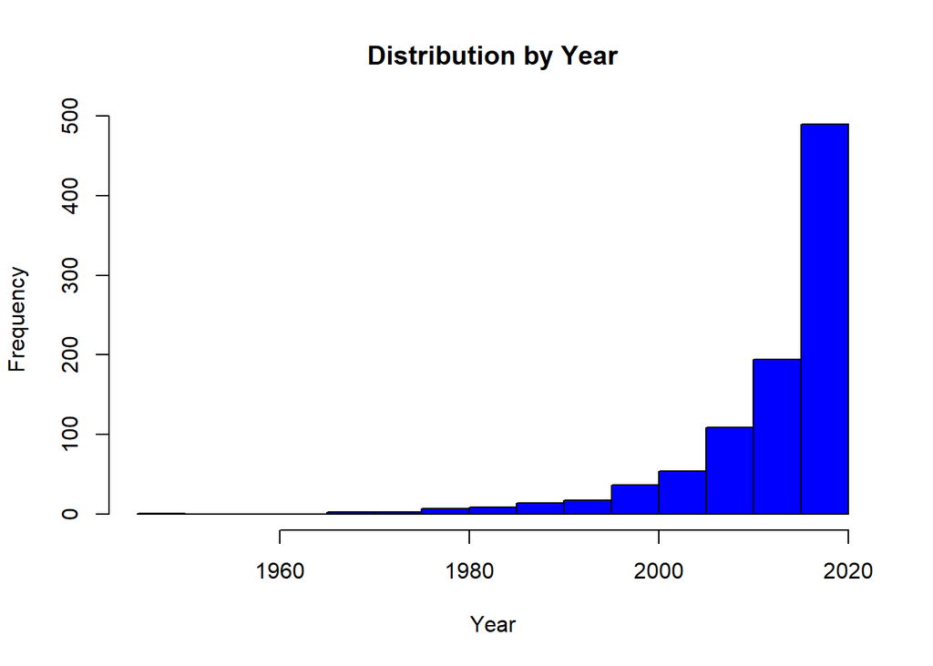

```r
hist(mov$Year, main="Distribution by Year", xlab = "Year", col = "blue")
```

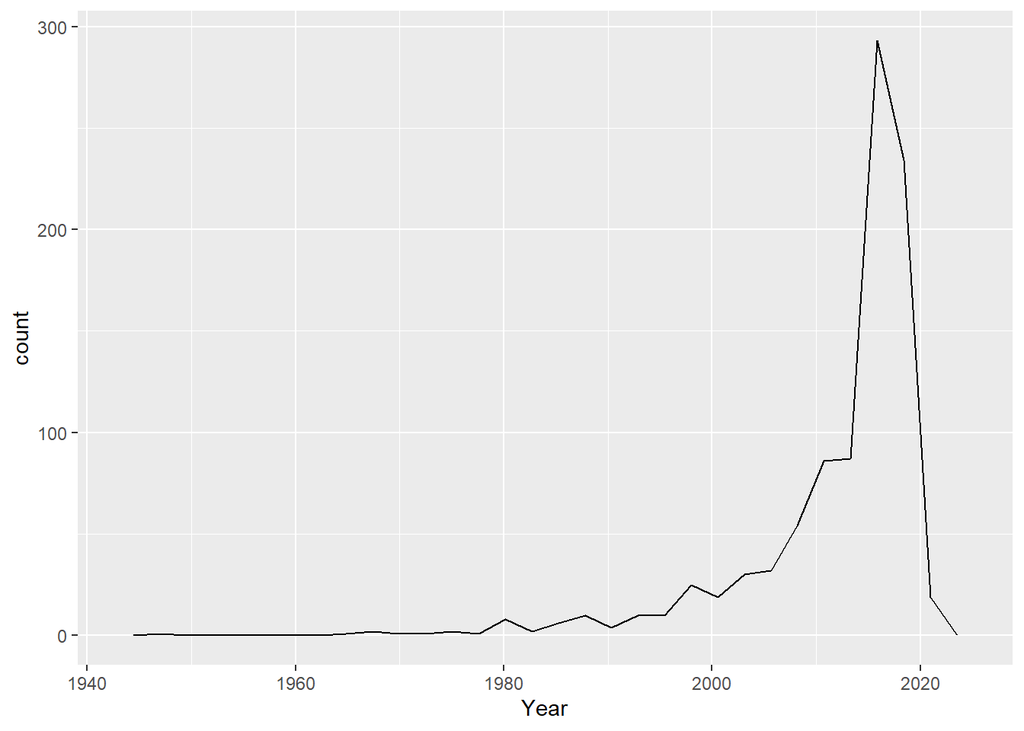

```r
ggplot(data=mov,aes(x=Year)) + geom_freqpoly(bins=30)
```

**This shows most of the movies are released in 2015 to 2020.**

## bivariate analysis

*scatter plot for bivariate analysis how does one variable change wrt another*

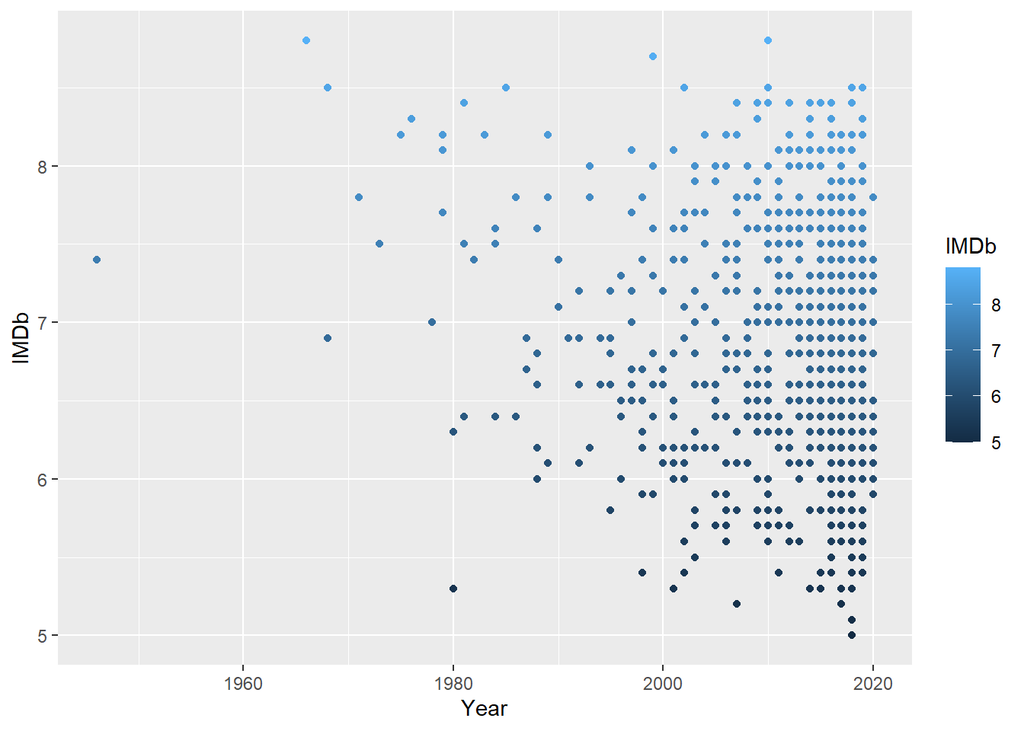

```r
ggplot(data=mov,aes(x=Year, y=IMDb,col=IMDb)) + geom_point()
```

## Smooth-Line

*smooth-line for checking how does one continuous variable change wrt another continuous variable*

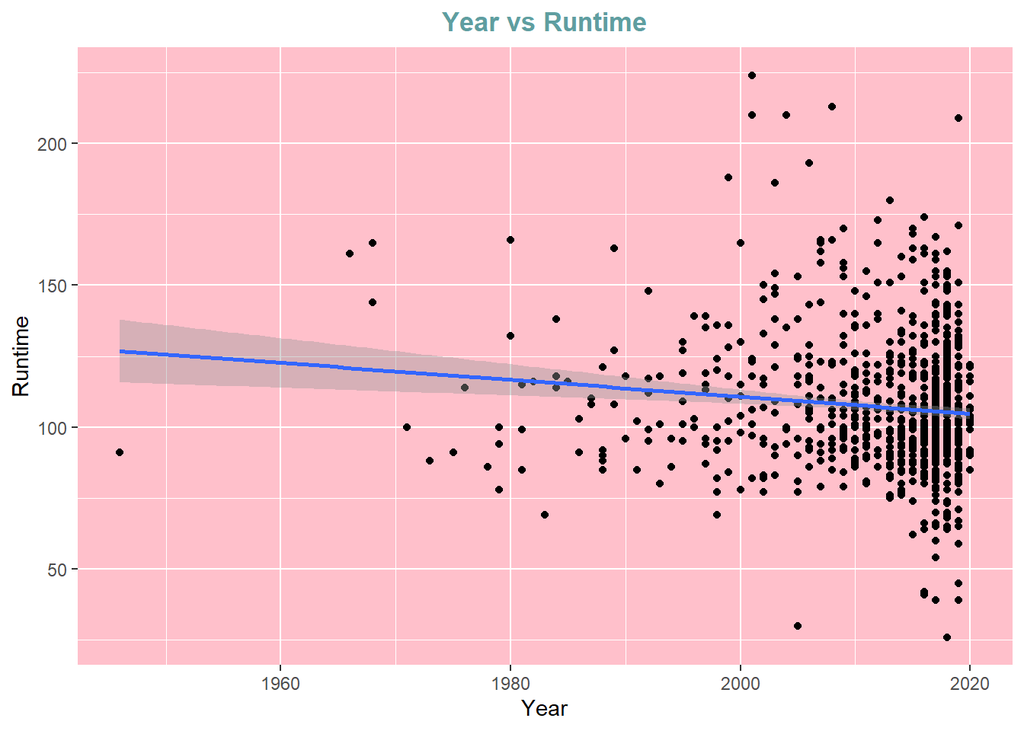

```r
  g1<-ggplot(data=mov,aes(x=Year,y=Runtime)) +geom_point()+ geom_smooth(method="lm") #lm is linear-model
  g1+ theme(panel.background = element_rect(fill="pink"),plot.title=element_text(hjust=0.5,face="bold",color="cadetblue")) + labs(title = "Year vs Runtime")
```

**This shows from previous year, now the released movies duration has decreased to 100-120 mins.**

## Boxplot

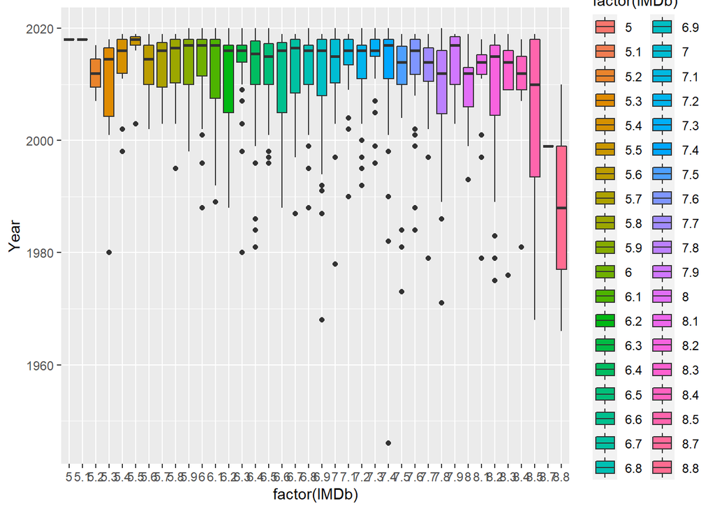

```r
ggplot(data=mov,aes(x=factor(IMDb),y=Year, fill=factor(IMDb))) + geom_boxplot()
```

# **Conclusions from the Graphs**

## *Question 1: Which release years had the most number of movies shot?*

```r
popular_by_year <- mov %>%
  group_by(Year) %>%
  summarize(Number_of_movies = n_distinct(Title)) %>%
  filter(Number_of_movies > 5) %>%
  arrange(desc(Number_of_movies))
popular_by_year
```

```
## # A tibble: 25 x 2
##     Year Number_of_movies
##    <int>            <int>
##  1  2018              143
##  2  2017              140
##  3  2016               96
##  4  2019               91
##  5  2015               57
##  6  2014               53
##  7  2010               36
##  8  2013               34
##  9  2011               27
## 10  2009               23
## # ... with 15 more rows
```

## This can be easily understood if it is visualized.

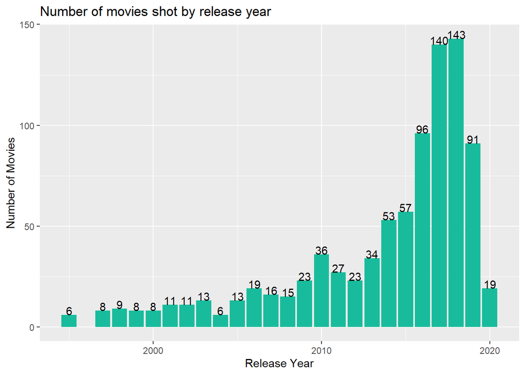

```r
popular_by_year %>%
  ggplot(aes(x = Year, y = Number_of_movies)) +

  geom_col(fill = "#18BC9C") +
  geom_text(aes(label= Number_of_movies), vjust = 0 ) +
  labs(
    title = "Number of movies shot by release year",
    x = "Release Year",
    y = "Number of Movies"
  )
```

### **In 2018 most of the movies were shot.**

## Question 2: Which are the most famous locations to shoot a movie?

```r
popular_locations <- mov %>%
group_by(Country) %>%
summarize(Number_of_movies = n_distinct(Title)) %>%
filter(Number_of_movies > 5) %>%
filter(Number_of_movies < 54) %>%
arrange(desc(Number_of_movies))
popular_locations
```

```
## # A tibble: 11 x 2
##    Country                      Number_of_movies
##    <chr>                                   <int>
##  1 United Kingdom                             27
##  2 United Kingdom,United States               25
##  3 Canada                                     20
##  4 Australia                                  13
##  5 United States,United Kingdom               13
##  6 Spain                                      12
##  7 Japan                                      11
##  8 Germany,United States                       9
##  9 Canada,United States                        8
## 10 France                                      8
## 11 United States,Canada                        7
```

## Visualizing this…

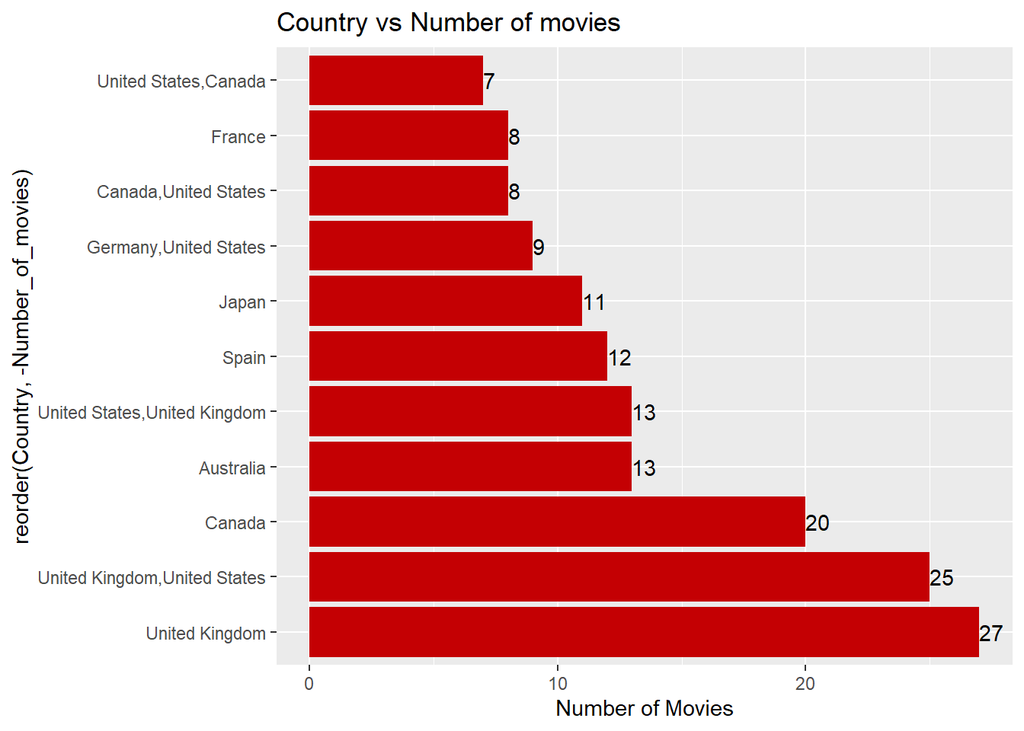

```r
popular_locations %>%
ggplot(aes(x = reorder(Country, -Number_of_movies), y = Number_of_movies )) +

geom_col(fill = "#C40003" ) +
geom_text(aes(label= Number_of_movies), hjust = 0 ) +
labs (
  title = "Country vs Number of movies",
  y = "Number of Movies"
) +
coord_flip()
```

## Question 3: Which directors shot the most number of movies?

```r
directors <- mov %>%
group_by(Directors) %>%
summarize(Number_of_movies = n_distinct(Title)) %>%
filter(Number_of_movies > 3) %>%
arrange(desc(Number_of_movies))
directors
```

```
## # A tibble: 6 x 2
##   Directors                      Number_of_movies
##   <chr>                                     <int>
## 1 Steven Spielberg                              7
## 2 Jay Roach                                     5
## 3 Noah Baumbach                                 5
## 4 Robert Zemeckis                               5
## 5 Jeremy Saulnier                               4
## 6 Lana Wachowski,Lilly Wachowski                4
```

## Visualizing this …

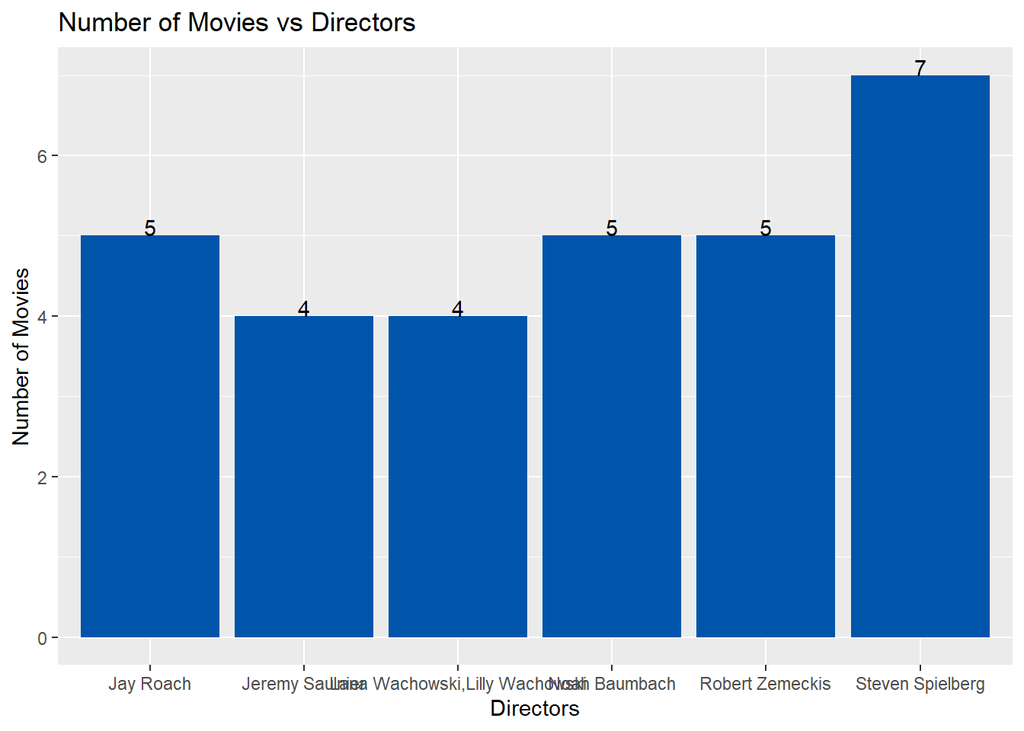

```r
directors %>%
  ggplot(aes(x = Directors, y = Number_of_movies )) +

  geom_col(fill = "#0055AA" ) +
    geom_text(aes(label= Number_of_movies), vjust = 0 ) +
  labs (
    title = "Number of Movies vs Directors",
    y = "Number of Movies"
  )
```

### **Clearly Steven Spielberg released most number of Movies.**

## Ques4 Who are the top ten directors with best movie ?

```r
best_director<-mov%>%group_by(Directors)%>%
  summarise(mean= mean(IMDb))%>%
  top_n(10)%>%
  arrange(desc(mean))
best_director
```

```
## # A tibble: 12 x 2
##    Directors                                    mean
##    <chr>                                       <dbl>
##  1 Christopher Nolan                            8.8
##  2 Sergio Leone                                 8.65
##  3 Anthony Russo,Joe Russo                      8.5
##  4 Asif Kapadia                                 8.5
##  5 Roman Polanski                               8.5
##  6 Stan Lathan                                  8.5
##  7 Thom Zimny                                   8.5
##  8 Aamir Khan,Amole Gupte                       8.4
##  9 Bob Persichetti,Peter Ramsey,Rodney Rothman  8.4
## 10 Evgeny Afineevsky                            8.4
## 11 Nitesh Tiwari                                8.4
## 12 Sam Dunn,Scot McFadyen                       8.4
```

##plot the top 10 directors with their average score for better visualization

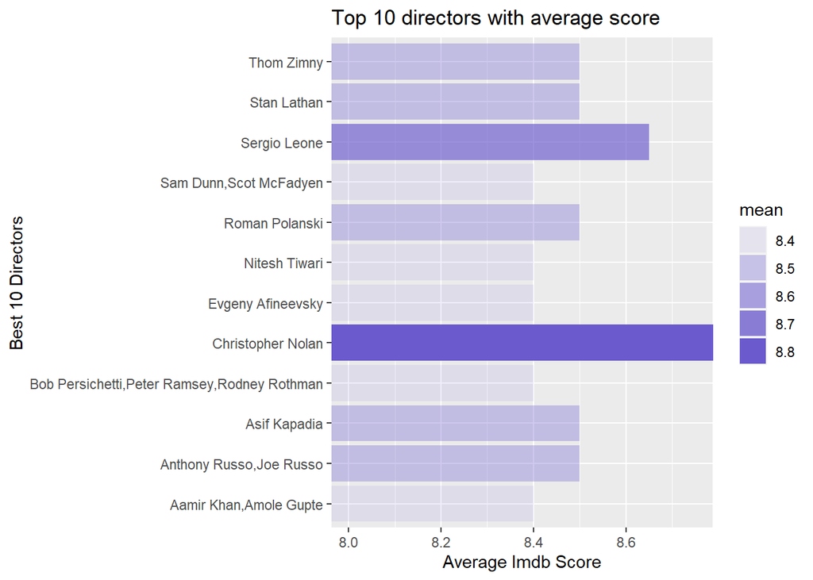

```r
ggplot(best_director, aes(x = Directors, y = mean, alpha = mean))+
  geom_bar(stat = "identity",fill = "slateblue") + labs(x = "Best 10 Directors", y = "Average Imdb Score") +
  ggtitle("Top 10 directors with average score")+coord_flip(ylim=c(8,8.75))
```

### **From the previous graph we can see most movies were directed by Steven Spielberg but from this graph we can conclude that the best rated movies were directed by Christopher Nolan**

## Ques5 What are the Most Liked Genre among Movies?

```r
best_category<-mov%>%
  group_by(Genres)%>%
  summarise(mean= mean(IMDb))%>%
  top_n(5)%>%
  arrange(desc(mean))
best_category
```

```
## # A tibble: 5 x 2
##   Genres                                    mean
##   <chr>                                    <dbl>
## 1 Western                                   8.65
## 2 Biography,Drama,Music,War                 8.5
## 3 Animation,Action,Adventure,Family,Sci-Fi  8.4
## 4 Adventure,Drama,War                       8.3
## 5 Crime,Drama,Mystery                       8.3
```

## plot

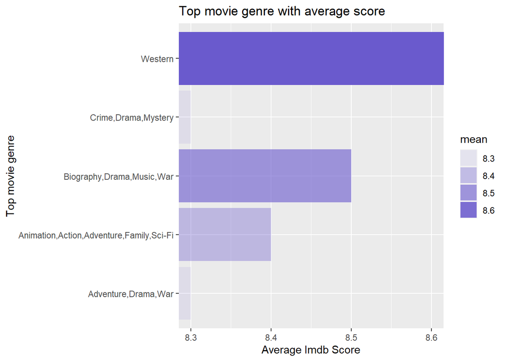

```r
ggplot(best_category, aes(x = Genres, y = mean, alpha = mean))+
  geom_bar(stat = "identity",fill = "slateblue") + labs(x = "Top movie genre", y = "Average Imdb Score") +
  ggtitle("Top movie genre with average score")+coord_flip(ylim=c(8.3,8.6))
```

### **So as we can see Western movies are mostly liked by the audience.**